# Homework - Week 3

Author

Group 2

# Homework instructions

Explore this dataset about Trump tweets.

Here’s some ideas:

- Sentiment Analysis over time
- Sentiment Analysis for tweets containing certain **hashtags** / **keywords** (what / whom is trump talking positively about, whom is he talking negatively about?) -
- Complexity Analysis over time
- Relationship between Sentiment and Likes/Retweets

Try out some other dictionary style analyses, for instance using the “nrc” **emotion** dictionary, or the **moral** foundations dictionary (https://osf.io/ezn37/)

## About the data

| Variables | Description |
| --- | --- |
| isRetweet | whether the tweet is a retweeted tweet |
| isDeleted | whether the tweet has been deleted |
| device | from which device the tweet was sent (there is a theory that tweets from **iPhone** come from Trump directly, **other** tweets, like those from TweetDeck are by the Trump team) |
| favorites | number of likes a tweet got |
| retweets | number of retweets the tweet got |
| date | date of the tweet |
| isFlagged | a bit unsure what this means, potentially flagged tweets contain misinformation |

This data stems from Kaggle: https://www.kaggle.com/datasets/codebreaker619/donald-trump-tweets-dataset

# Setup

## Load packages

Add packages you need here…

```r
knitr::opts_chunk$set(echo = TRUE)
p_needed <-
  c("textdata",
    "tidyverse",
    "tidytext",              # some helpful functions for tidying text
    "quanteda",              # one of the biggest text data R packages out there
    "quanteda.textstats",    # some extra functions, e.g. calculating complexity
    "quanteda.textplots",    # Plots for visualising textual data
    "sentimentr",            # for advanced sentiment analysis
    "SnowballC"              # for stemming
    )

packages <- rownames(installed.packages())
p_to_install <- p_needed[!(p_needed %in% packages)]

if (length(p_to_install) > 0) {
  install.packages(p_to_install)
}
sapply(p_needed, require, character.only = TRUE)
```

```
          textdata          tidyverse           tidytext           quanteda
              TRUE               TRUE               TRUE               TRUE
quanteda.textstats quanteda.textplots         sentimentr          SnowballC
              TRUE               TRUE               TRUE               TRUE
```

## Load data

Specify the correct path depending on your system. Remember to work in a project so you can use relative paths from your project directory. The code below assumes that in your project directory (where your .rproject file lives) exists a folder that’s called Homework, and that in this folder, there’s a file called donald_tweets.csv.

To render this document, make sure to put the relative file path into the here::here() function, which keeps working directories consistent:

```r
tweets <- read_csv("donald_tweets.csv")

# lapply(tweets, class)
# unique(tweets$device)
```

# Descriptive overview

Provide some descriptive overview over the data here (e.g. using skimr, but also perhaps some helpful plots regarding the distribution of variables). Some questions to answer:

```r
skimr::skim(tweets) %>% DT::datatable()
```

|  | skim_type | skim_variable | n_missing | complete_rate | POSIXct.min | POSIXct.max | POSIXct.median | POSIXct.n_unique | character.min | character.max | character.empty | character.n_unique | character.whitespace | logical.mean | logical.count | numeric.mean | numeric.sd | numeric.p0 | numeric.p25 | numeric.p50 | numeric.p75 | numeric.p100 | numeric.hist |
| --- | --- | --- | --- | --- | --- | --- | --- | --- | --- | --- | --- | --- | --- | --- | --- | --- | --- | --- | --- | --- | --- | --- | --- |
| 1 | POSIXct | date | 0 | 1 | 2009-05-04T18:54:25Z | 2021-01-08T15:44:28Z | 2016-06-26T16:21:15Z | 56022 |  |  |  |  |  |  |  |  |  |  |  |  |  |  |  |
| 2 | character | text | 0 | 1 |  |  |  |  | 2 | 328 | 0 | 56118 | 0 |  |  |  |  |  |  |  |  |  |  |
| 3 | character | device | 0 | 1 |  |  |  |  | 8 | 24 | 0 | 20 | 0 |  |  |  |  |  |  |  |  |  |  |
| 4 | logical | isRetweet | 0 | 1 |  |  |  |  |  |  |  |  |  | 0.174594757030988 | FAL: 46694, TRU: 9877 |  |  |  |  |  |  |  |  |
| 5 | logical | isDeleted | 0 | 1 |  |  |  |  |  |  |  |  |  | 0.0193031765392162 | FAL: 55479, TRU: 1092 |  |  |  |  |  |  |  |  |
| 6 | logical | isFlagged | 0 | 1 |  |  |  |  |  |  |  |  |  | 0.00537377808417741 | FAL: 56267, TRU: 304 |  |  |  |  |  |  |  |  |
| 7 | numeric | id | 0 | 1 |  |  |  |  |  |  |  |  |  |  |  | 7.98786539675064e+17 | 3.82661565492123e+17 | 1698308935 | 4.60619237292519e+17 | 7.47102432862274e+17 | 1.19313404179452e+18 | 1.34756987057827e+18 | ▂▆▅▂▇ |
| 8 | numeric | favorites | 0 | 1 |  |  |  |  |  |  |  |  |  |  |  | 28349.5539587421 | 57815.6352598278 | 0 | 10 | 164 | 43938.5 | 1869706 | ▇▁▁▁▁ |
| 9 | numeric | retweets | 0 | 1 |  |  |  |  |  |  |  |  |  |  |  | 8618.98746707677 | 13306.1324077579 | 0 | 59 | 3450 | 13014.5 | 408866 | ▇▁▁▁▁ |

- How many tweets do we have?

  ```r
  nrow(tweets)
  ```

  ```
  [1] 56571
  ```

- What time range do tweets fall in?

  ```r
  min(tweets$date)
  ```

  ```
  [1] "2009-05-04 18:54:25 UTC"
  ```

  ```r
  max(tweets$date)
  ```

  ```
  [1] "2021-01-08 15:44:28 UTC"
  ```

- What is the development of number of tweets over time?

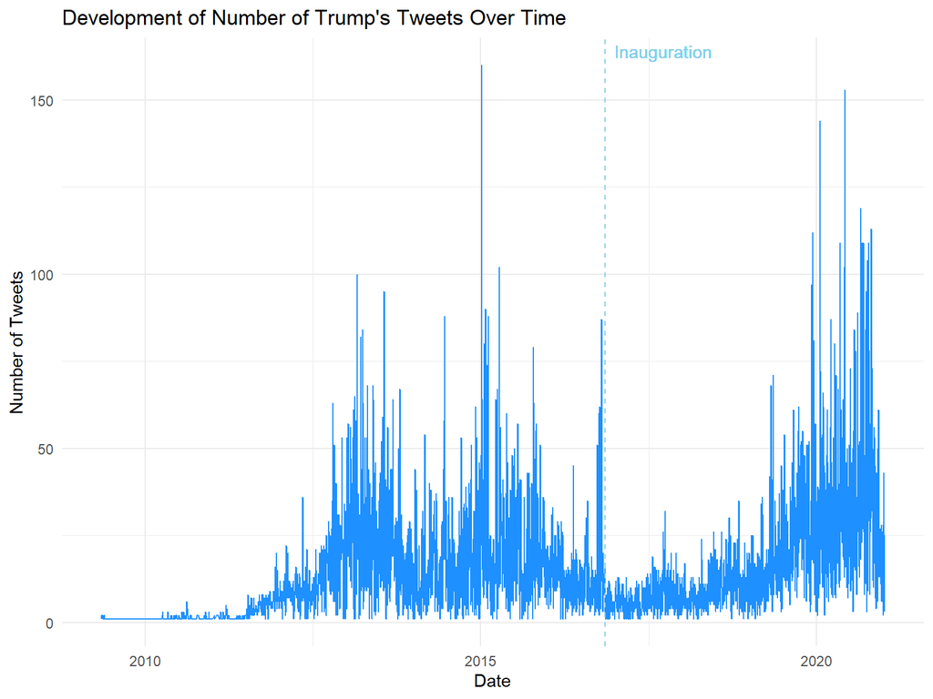

  ```r
  inauguration_date <- as.Date("2016-11-09")

  # Plot Version 1
  tweets %>%
    mutate(date = as.Date(date)) %>%
    group_by(date) %>%
    summarize(num_tweets = n()) %>%

    ggplot(aes(x = date, y = num_tweets)) +
    geom_line(color="dodgerblue") +
    geom_vline(xintercept = inauguration_date,
               linetype = "dashed",
               color = "skyblue") +
    geom_text(x = inauguration_date, y = Inf,
              label = "Inauguration",
              vjust = 1.5, hjust = -0.1, color = "skyblue") +
    labs(
      title = "Development of Number of Trump's Tweets Over Time",
      x = "Date",
      y = "Number of Tweets") +
    theme_minimal()
  ```

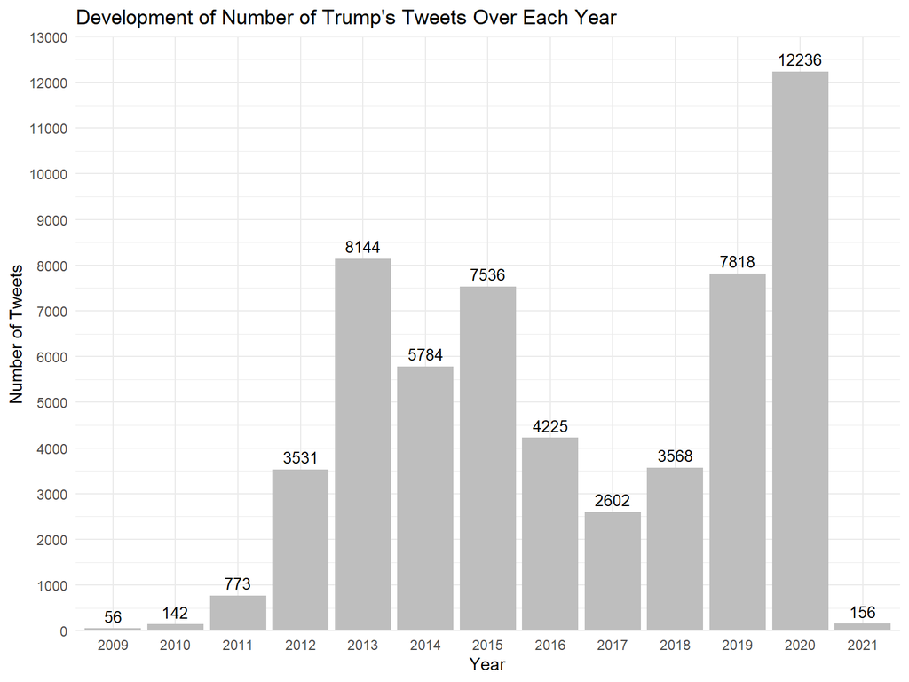

  ```r
  # Plot Version 2
  tweets %>%
    mutate(year = year(date) %>% as.factor()) %>%
    group_by(year) %>%
    summarise(count_tweet = n()) %>%

    ggplot(aes(year, count_tweet)) +
    geom_text(aes(label=count_tweet), vjust=-0.5, size = 3.5) +
    geom_bar(stat = "identity", fill= "grey") +
    labs(
      title = "Development of Number of Trump's Tweets Over Each Year",
      x = "Year",
      y = "Number of Tweets") +
    theme_minimal() +
    scale_y_continuous(limits = c(0, 13000),
                       breaks = seq(0, 13000, by = 1000),
                       expand = c(0, 0))
  ```

- What is the development of likes / shares over time?

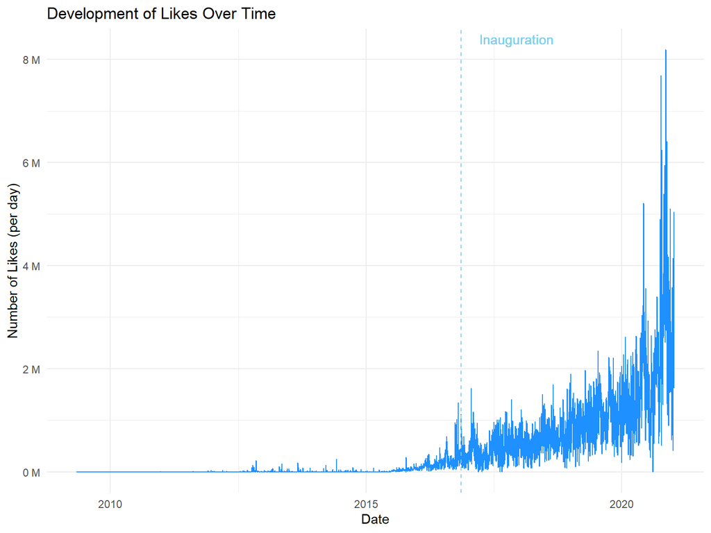

  ```r
  inauguration_date <- as.Date("2016-11-09")

  # Plot no. of Likes over time
  tweets %>%
    mutate(date = as.Date(date)) %>%
    group_by(date) %>%
    summarize(total_likes = sum(favorites)) %>%

    ggplot(aes(x = date, y = total_likes)) +
    geom_line(color="dodgerblue") +
    geom_vline(xintercept = inauguration_date,
               linetype = "dashed",
               color = "skyblue") +
    geom_text(x = inauguration_date, y = Inf,
              label = "Inauguration",
              vjust = 1.5, hjust = -0.25, color = "skyblue") +
    labs(
      title = "Development of Likes Over Time",
      x = "Date",
      y = "Number of Likes (per day)"
    ) +
    scale_y_continuous(labels = scales::unit_format(unit = "M", scale = 1e-6)) +
    theme_minimal()
  ```

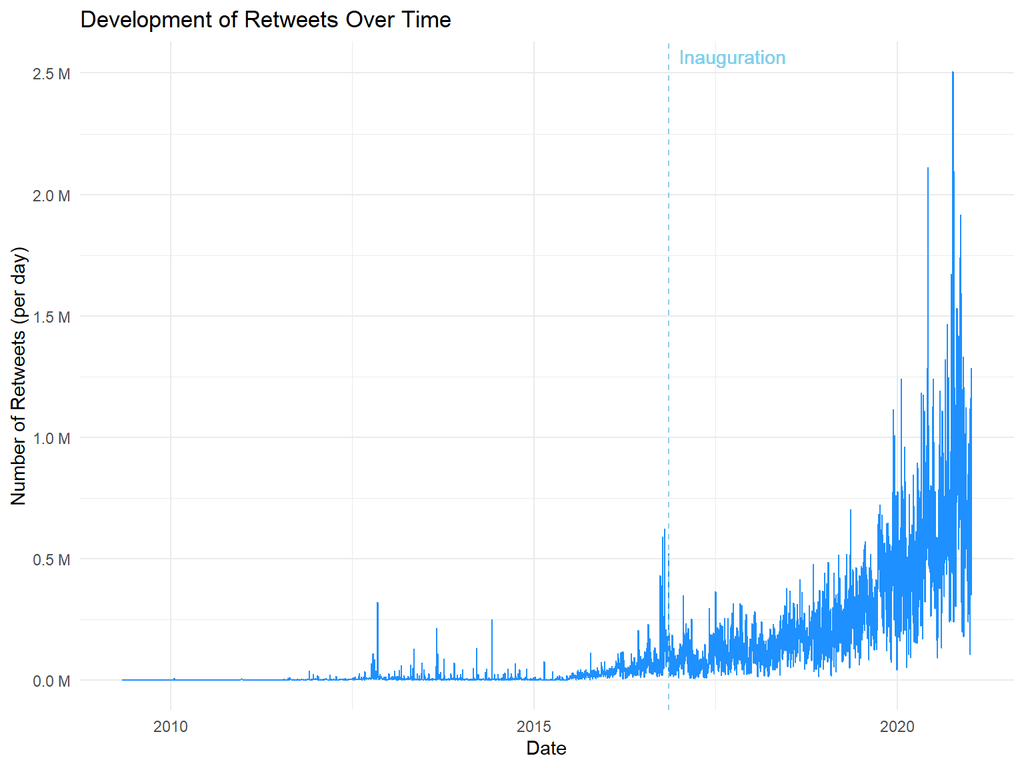

  ```r
  # Plot no. of Retweets over time
  tweets %>%
    mutate(date = as.Date(date)) %>%
    group_by(date) %>%
    summarize(total_retweets = sum(retweets)) %>%

    ggplot(aes(x = date, y = total_retweets)) +
    geom_line(color="dodgerblue") +
    geom_vline(xintercept = inauguration_date,
               linetype = "dashed",
               color = "skyblue") +
    geom_text(x = inauguration_date, y = Inf,
              label = "Inauguration",
              vjust = 1.5, hjust = -0.1, color = "skyblue") +
    labs(
      title = "Development of Retweets Over Time",
      x = "Date",
      y = "Number of Retweets (per day)"
    ) +
    scale_y_continuous(labels = scales::unit_format(unit = "M", scale = 1e-6)) +
    theme_minimal()
  ```

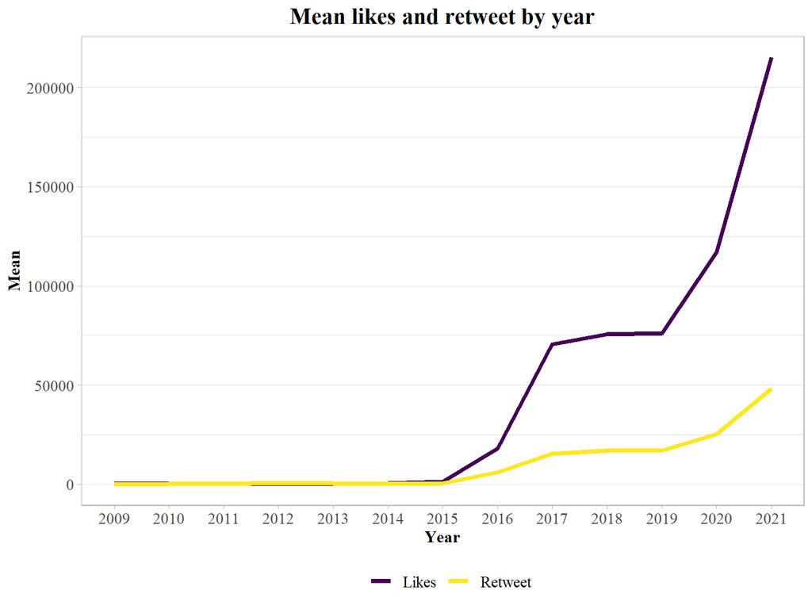

  ```r
  # Mean Likes & Retweets per Year

  tweets %>%
    filter(favorites > 0) %>% # remove tweets eith zero likes - retweets?
    mutate(year = year(date) %>%  as.factor()) %>%
    group_by(year) %>%
    summarise(mean_likes = mean(favorites),
              mean_retweet = mean(retweets)) %>%
    pivot_longer(cols = !year, names_to = "popular", values_to = "mean") %>%

    ggplot(aes(year, mean, color = popular, group=popular)) +
    geom_line(size=1.5) +
    scale_color_viridis_d(labels = c("Likes", "Retweet")) +
    theme_light() +
    theme(panel.grid.major.x = element_blank(),
          plot.title = element_text(hjust = 0.5, face = "bold", size = 16),
          axis.title = element_text(face="bold", size = 12),
          legend.position = "bottom",
          text = element_text(size = 14, family = "serif")) +
    labs(title = "Mean likes and retweet by year",
         y = "Mean",
         x = "Year",
         color = " ")
  ```

# Preprocess

Preprocess the data here (e.g. tokenization, stopword removal, …).

```r
tidy_tweets <- tweets %>%
  tidytext::unnest_tokens(sentence, text, token = "sentences") %>%
  group_by(id) %>%
  mutate(sentence_id = row_number()) %>%
  ungroup() %>%
  tidytext::unnest_tokens(word, sentence, token = "words", drop = FALSE) %>%
  anti_join(tidytext::get_stopwords())
```

# Analyse & Plot

```r
tidy_tweets %>%
  count(word, sort = TRUE) %>%
  head(50) %>%
  DT::datatable()
```

|  | word | n |
| --- | --- | --- |
| 1 | t.co | 16669 |
| 2 | https | 12204 |
| 3 | realdonaldtrump | 10945 |
| 4 | rt | 10167 |
| 5 | great | 7672 |
| 6 | trump | 6573 |
| 7 | amp | 5682 |
| 8 | president | 4699 |
| 9 | http | 4550 |
| 10 | thank | 3609 |

[output cut: 40 more lines]

```r
afinn_dic <- tidytext::get_sentiments(lexicon = "afinn")
nrc_dic <- tidytext::get_sentiments(lexicon = "nrc")
bing_dic <- tidytext::get_sentiments(lexicon = "bing")
data_dictionary_LSD2015_pos_neg <- data_dictionary_LSD2015[1:2]
#moral_dic <- tidytext::get_sentiments(lexicon = "moral")
```

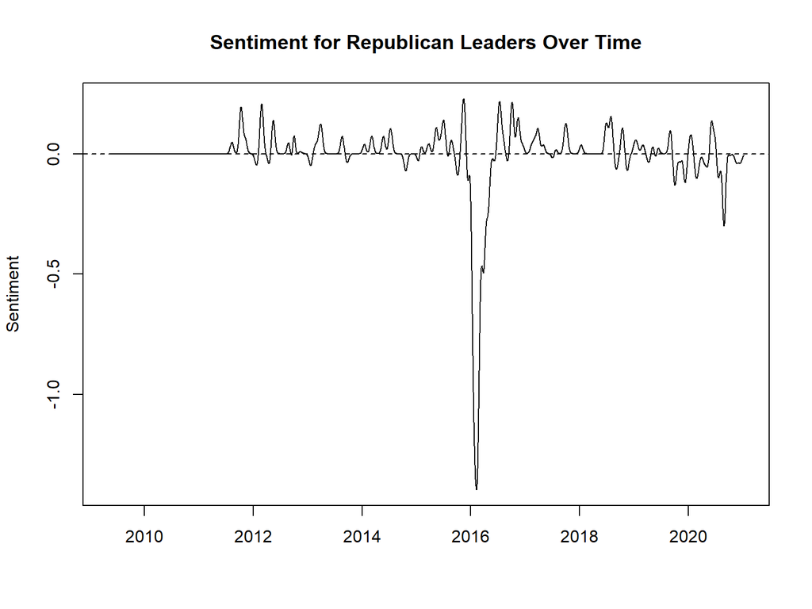

```r
# Look at words/phrases that are used 'pre' and 'post' of the word "war", allow you look at the 'sentiments' surrounding (pre/post) the word.

tweets_corpus <- tweets %>%
  mutate(date = as.Date(date)) %>%
  quanteda::corpus()

# Define a function to plot sentiment over time for specific keywords
plot_sentiment_over_time <- function(keywords, group_name,
                                     tweets_corpus,
                                     data_dictionary_LSD2015_pos_neg) {
  toks_keywords <- tweets_corpus %>%
    tokens(remove_punct = TRUE) %>%
    tokens_keep(pattern = phrase(keywords),
                window = 10) %>%
    tokens_lookup(dictionary = data_dictionary_LSD2015_pos_neg) %>%
    dfm() %>%
    dfm_group(groups = date)
  dat_smooth <- ksmooth(x = toks_keywords$date,
                        y = toks_keywords[,"positive"] - toks_keywords[,"negative"],
                        kernel = "normal", bandwidth = 30)

  plot(dat_smooth$x, dat_smooth$y, type = "l", # Create the plot
       ylab = "Sentiment", xlab = "",
       main = paste("Sentiment for", group_name, "Over Time"))
  abline(h = 0, lty = 2) }

# Sentiments about Republican Leaders
republicans <- c("Pence", "Romney", "Ted", "Cruz")
plot_sentiment_over_time(republicans, "Republican Leaders",
                         tweets_corpus, data_dictionary_LSD2015_pos_neg)
```

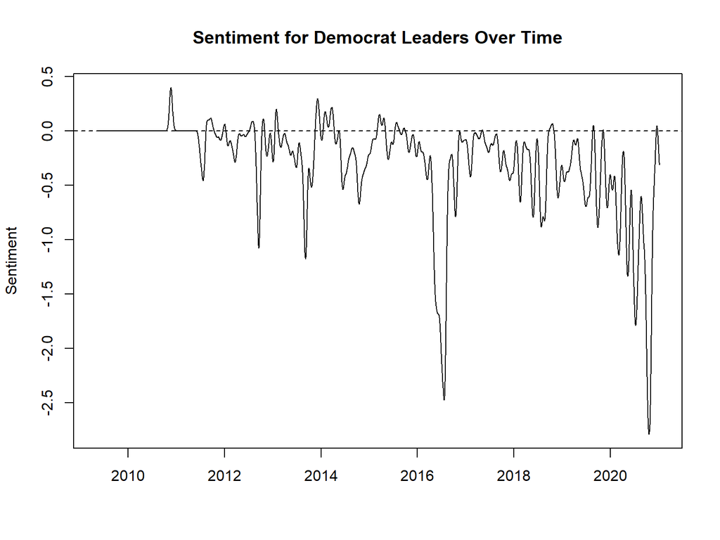

```r
# Sentiments about Democrat Leaders
democrats <- c("Biden", "Obama", "Clinton", "Bernie")
plot_sentiment_over_time(democrats, "Democrat Leaders",
                         tweets_corpus, data_dictionary_LSD2015_pos_neg)
```

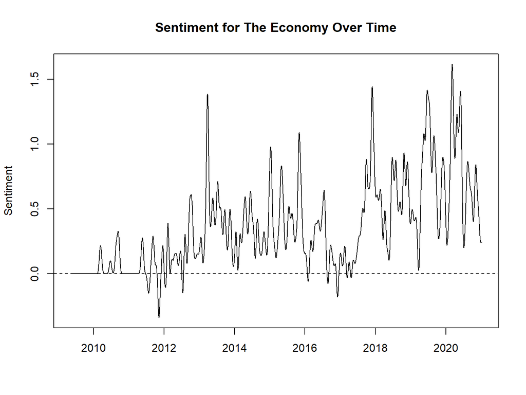

```r
# Sentiments about The Economy
economy <- c("Job", "Market", "Tax", "Employment")
plot_sentiment_over_time(economy, "The Economy",
                         tweets_corpus, data_dictionary_LSD2015_pos_neg)
```

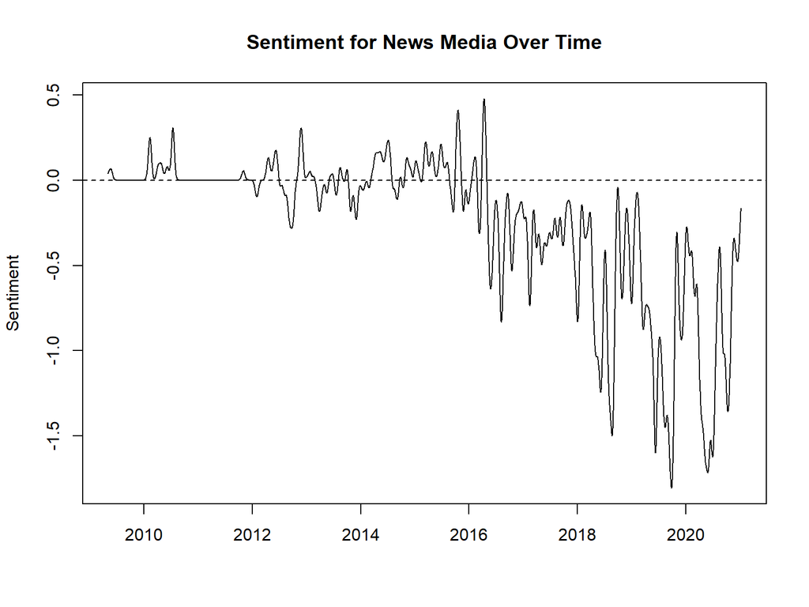

```r
# Sentiments about News Media
news_media <- c("CNN", "Mainstream", "Media", "New York")
plot_sentiment_over_time(news_media, "News Media",
                         tweets_corpus, data_dictionary_LSD2015_pos_neg)
```

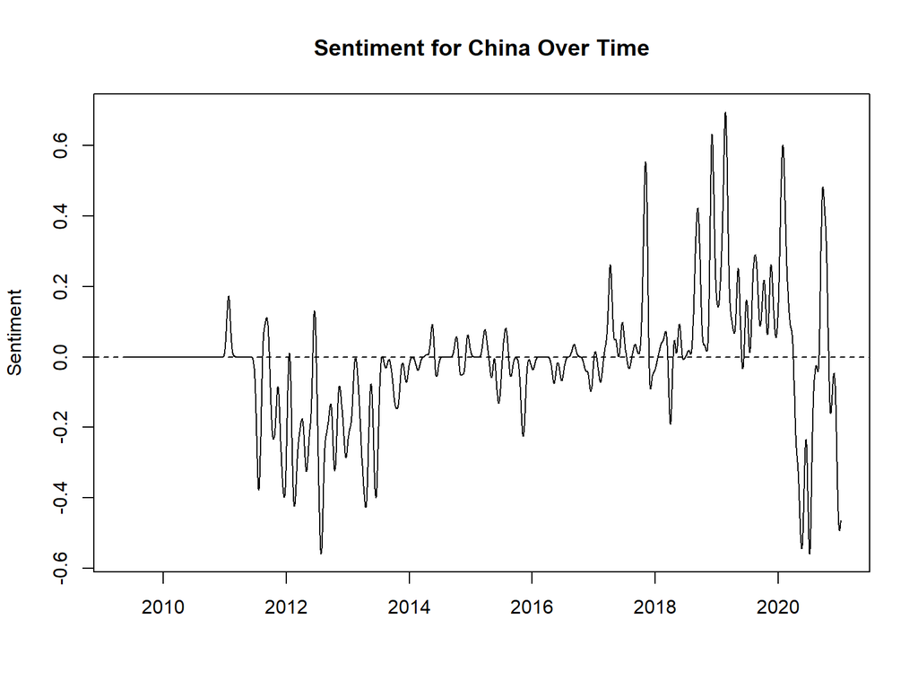

```r
# Sentiments about China
China <- c("China", "Xi", "Jinping")
plot_sentiment_over_time(China, "China",
                         tweets_corpus, data_dictionary_LSD2015_pos_neg)
```

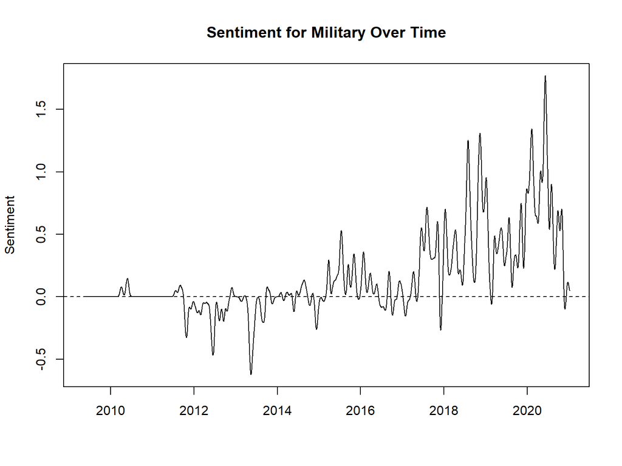

```r
# Sentiments about Military
Military <- c("Military", "Security", "Veterans")
plot_sentiment_over_time(Military, "Military",
                         tweets_corpus, data_dictionary_LSD2015_pos_neg)
```

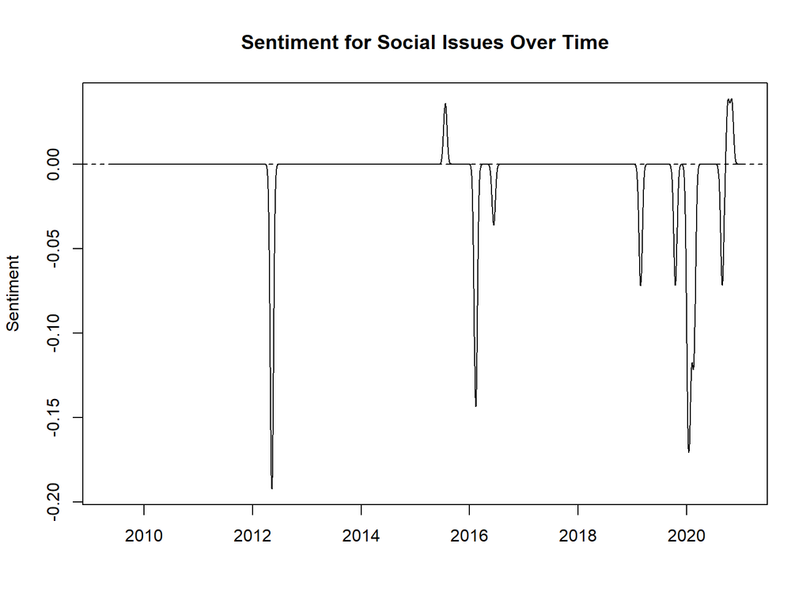

```r
# Sentiments about Social_Issues
Social_Issues <- c("Abortion", "Gay", "LGBTQ")
plot_sentiment_over_time(Social_Issues, "Social Issues",
                         tweets_corpus, data_dictionary_LSD2015_pos_neg)
```

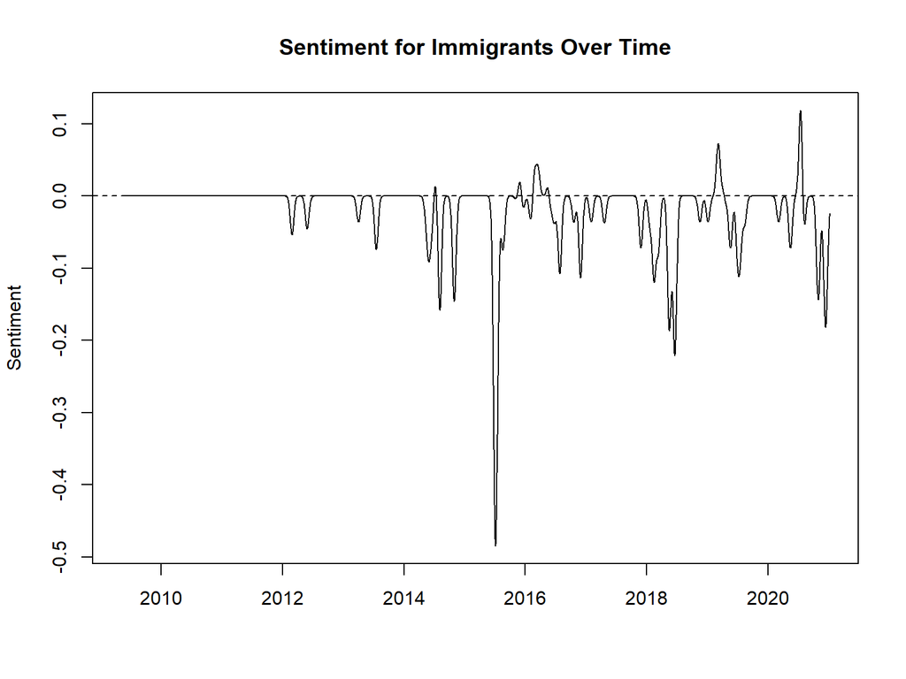

```r
# Sentiments about Immigrants
Immigrants <- c("Immigrants", "Refugee", "Refugees")
plot_sentiment_over_time(Immigrants, "Immigrants",
                         tweets_corpus, data_dictionary_LSD2015_pos_neg)
```

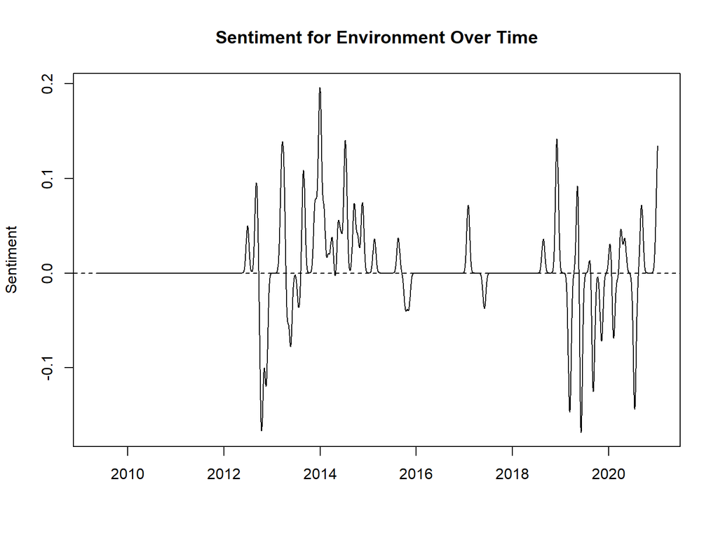

```r
# Sentiments about Environment
Environment <- c("Climate", "Environment")
plot_sentiment_over_time(Environment, "Environment",
                         tweets_corpus, data_dictionary_LSD2015_pos_neg)
```

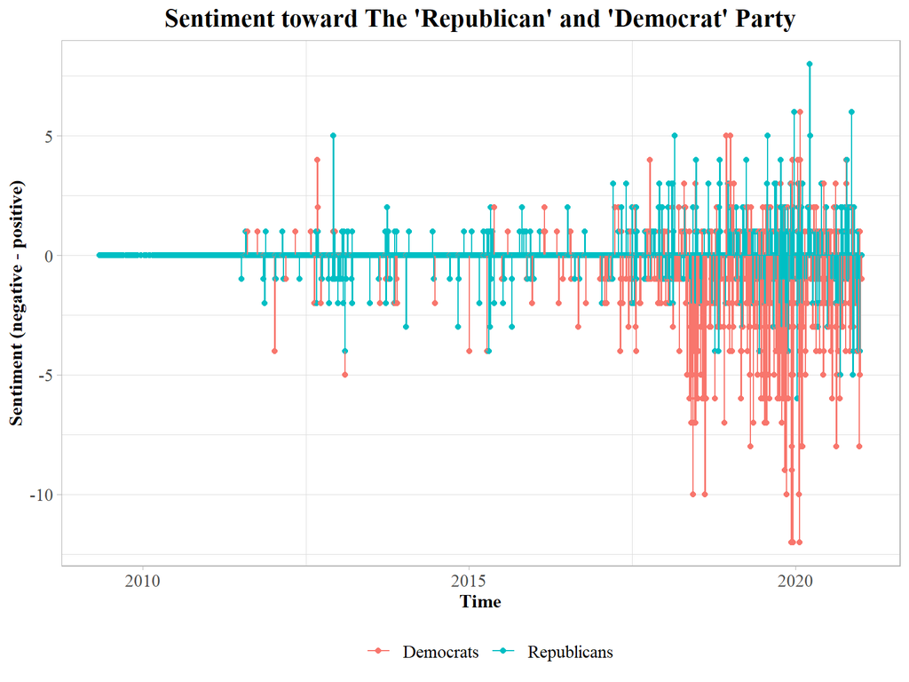

```r
# Sentiments about democrats
democrats <- c("Democrats")

republicans <- c("Republicans")

toks_dem <- tweets_corpus %>%
  tokens(remove_punct = TRUE) %>%
  tokens_keep(pattern = phrase(democrats),
              window = 10) %>%
  tokens_lookup(dictionary = data_dictionary_LSD2015_pos_neg) %>%
  dfm() %>%
  dfm_group(groups = date)

toks_rep <- tweets_corpus %>%
  tokens(remove_punct = TRUE) %>%
  tokens_keep(pattern = phrase(republicans),
              window = 10) %>%
  tokens_lookup(dictionary = data_dictionary_LSD2015_pos_neg) %>%
  dfm() %>%
  dfm_group(groups = date)

toks_dem <- convert(toks_dem, to = "data.frame")
toks_rep <- convert(toks_rep, to = "data.frame")

toks_dem <- mutate(toks_dem, sentiment_dem = positive-negative)

toks_rep <- mutate(toks_rep, sentiment_rep = positive-negative)

combined <- left_join(toks_dem, toks_rep, by ="doc_id")

combined %>%
  mutate(date = as.Date(doc_id)) %>%
  select(date, sentiment_dem, sentiment_rep) %>%
  pivot_longer(cols = !date, names_to = "party", values_to = "sentiment") %>%

  group_by(date, party) %>%

ggplot(aes(date, sentiment, color = party, group = party)) +
  geom_point() +
  geom_line() +
  theme_light() +
  theme(panel.grid.major.x = element_blank(),
        plot.title = element_text(hjust = 0.5, face = "bold", size = 16),
        axis.title = element_text(face="bold", size = 12),
        legend.position = "bottom",
        text = element_text(size = 14, family = "serif")) +
  labs(title = "Sentiment toward The 'Republican' and 'Democrat' Party",
       y = "Sentiment (negative - positive)",
       x = "Time",
       color = " ") +
  scale_color_discrete(labels = c("Democrats", "Republicans"))
```

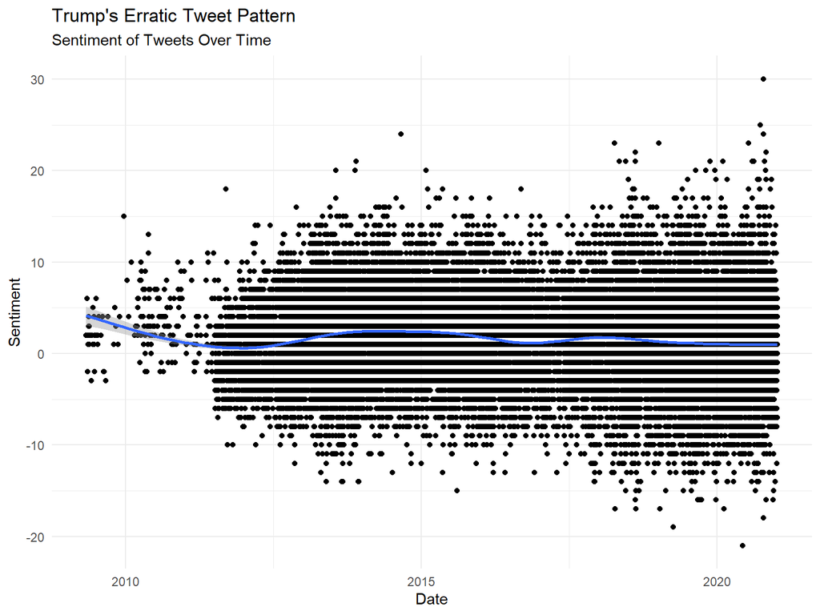

```r
# Sentiment of Tweet X Time (afinn_dic)
tidy_tweets %>%
  inner_join(afinn_dic) %>%
  mutate(date = as.Date(date)) %>%
  group_by(id, date) %>%
  summarise(sentiment = sum(value)) %>%

  ggplot(aes(date, sentiment)) +
  geom_point() +
  geom_smooth() +
  labs(title = "Trump's Erratic Tweet Pattern",
       subtitle = "Sentiment of Tweets Over Time",
       x = "Date", y = "Sentiment") +
  theme_minimal()
```

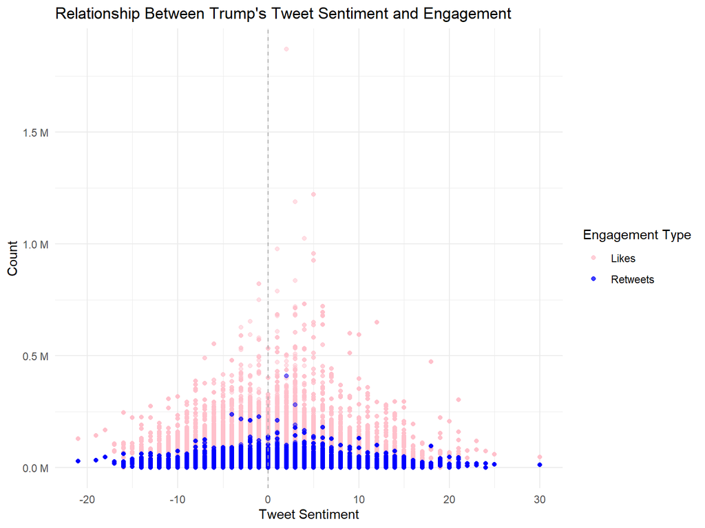

```r
# Sentiment of Tweet X Responses (afinn_dic)
tidy_tweets %>%
  inner_join(afinn_dic) %>%
  group_by(id) %>%
  reframe(sentiment = sum(value), retweets, favorites) %>%

  ggplot(aes(x = sentiment, y = retweets)) +
  geom_point(aes(y = favorites, color = "Likes"), alpha = 0.5) +
  geom_point(aes(color = "Retweets"), alpha = 0.5) +
  geom_vline(xintercept = 0, linetype = "dashed",
           color = "darkgrey") +
  labs(
    title = "Relationship Between Trump's Tweet Sentiment and Engagement",
    x = "Tweet Sentiment",
    y = "Count",
    color = "Engagement Type"
  ) +
  scale_color_manual(values = c("Retweets" = "blue", "Likes" = "pink")) +
  scale_y_continuous(labels = scales::unit_format(unit = "M", scale = 1e-6)) +
  theme_minimal()
```

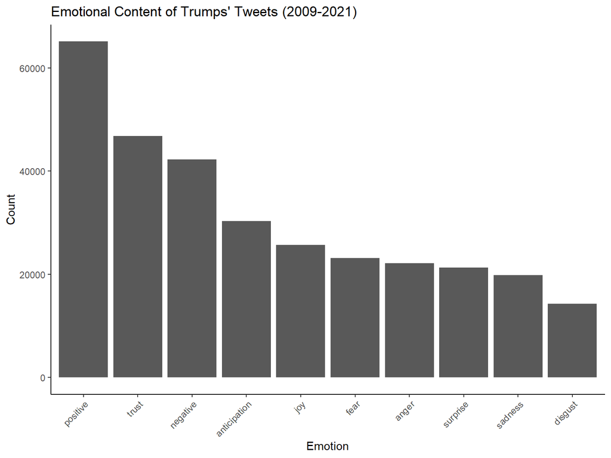

```r
# NRC Sentiment Categorical Variables:
# "trust"        "fear"         "negative"     "sadness"      "anger"   "surprise"     "positive"     "disgust"      "joy"          "anticipation"

# Emotions of All Tweets (nrc_dic)
tidy_tweets %>%
  inner_join(nrc_dic) %>%
  group_by(sentiment) %>%
  summarize(count = n()) %>%
  arrange(desc(count)) %>%

  ggplot(aes(x = reorder(sentiment, -count), y = count)) +
  geom_bar(stat = "identity") +
  labs(title = "Emotional Content of Trumps' Tweets (2009-2021)",
       x = "Emotion", y = "Count") +
  theme_classic() +
  theme(axis.text.x = element_text(angle = 45, hjust = 1))
```

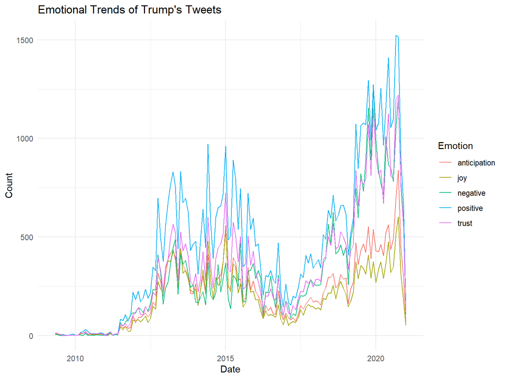

```r
# Emotions of All Tweets x Time (nrc_dic)
tidy_tweets %>%
  inner_join(nrc_dic) %>%
  filter(sentiment %in% c("positive", "trust",
                          "negative", "anticipation", "joy")) %>%
  mutate(date = as.Date(date)) %>%
  mutate(date_by_M = lubridate::floor_date(date, unit = "month")) %>%


  group_by(date_by_M, sentiment) %>%
  summarize(count = n()) %>%
  arrange(date_by_M) %>%

  ggplot(aes(x = date_by_M, y = count,
             color = sentiment)) +
  geom_line() +
  labs(title = "Emotional Trends of Trump's Tweets",
       x = "Date",
       y = "Count",
       color = "Emotion") +
  theme_minimal()
```

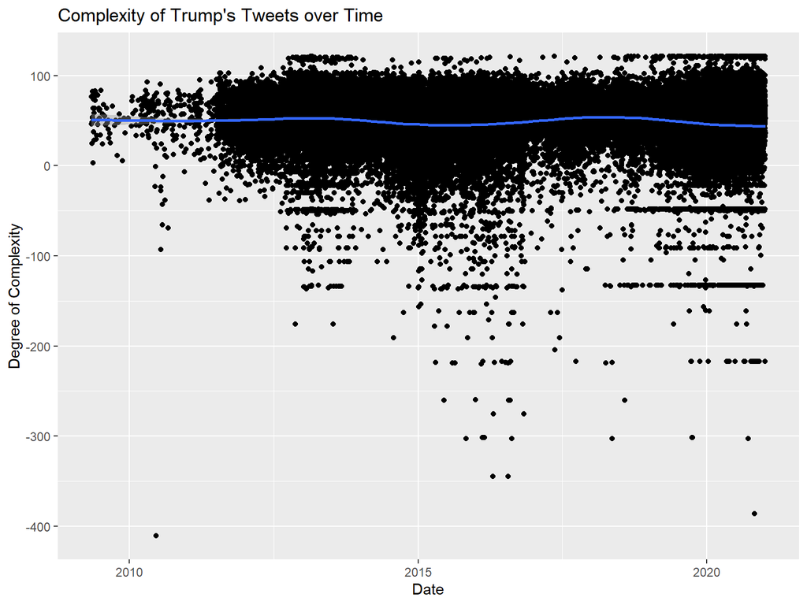

```r
complexity_df <- tweets %>%
  mutate(date = as.Date(date)) %>%
  mutate(textstat_readability(text))

complexity_df %>%
  filter(Flesch > -500) %>%

  ggplot(aes(date, Flesch)) +
  geom_point() +
  geom_smooth() +
  labs(title = "Complexity of Trump's Tweets over Time",
     x = "Date",
     y = "Degree of Complexity")
```

```r
#Remove punctuation, numbers and stop words
toks_nopunct <- tokens(tweets_corpus, remove_punct = TRUE)
dfmat_tweets <- dfm(toks_nopunct)
dfmat_tweets <- dfm_remove(dfmat_tweets, pattern = c(stopwords("en"), "*-time", "updated-*", "gmt", "bst"))
dfmat_tweets <- dfm_trim(dfmat_tweets, min_termfreq = 100)

#most frequent words
topfeatures(dfmat_tweets)
```

```
@realdonaldtrump               rt            great            trump
           11097            10156             7587             6326
             amp        president            thank           people
            5682             4654             3591             3483
            just              now
            3372             2669
```

```r
nfeat(dfmat_tweets)
```

```
[1] 1109
```

```r
fcmat_tweets <- fcm(dfmat_tweets)
dim(fcmat_tweets)
```

```
[1] 1109 1109
```

```r
feat <- names(topfeatures(fcmat_tweets, 50))
fcmat_tweets_select <- fcm_select(fcmat_tweets, pattern = feat, selection = "keep")
dim(fcmat_tweets_select)
```

```
[1] 50 50
```

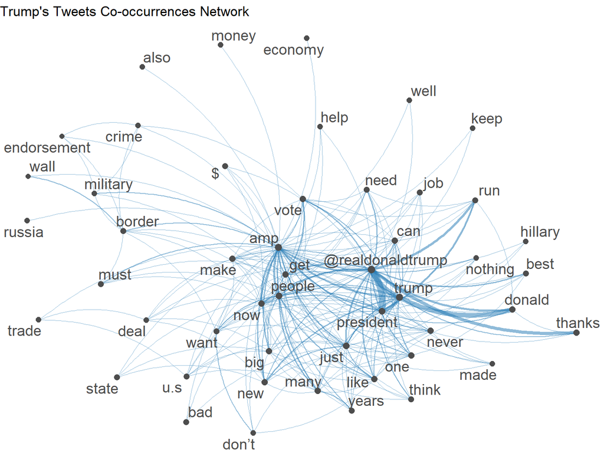

```r
#Plot
size <- log(colSums(dfm_select(dfmat_tweets, feat, selection = "keep")))

set.seed(144)
textplot_network(fcmat_tweets_select, min_freq = 0.8, vertex_size = size / max(size) * 3) + ggtitle("Trump's Tweets Co-occurrences Network")
```

Erratic Sentiment Fluctuations: Trump’s tweets exhibit a wide range of sentiment scores, from highly positive to strongly negative, reflecting the dynamic nature of his communication over time.”